# Statisztikai Kapcsolatvizsgálatok

## 1. A Kapcsolatvizsgálat alapfeladata

A Moodle-n található CSOK.xlsx fájl egy olyan adattábla, ami 15800 db véletlenszerűen kiválasztott eladó magyar ingatlanról (lakásról és kertes házról) 5 változó (oszlop) adatát tárolja:

- **price**: ház ára millió Ft-ban (MFt)
- **area**: ház területe négyzetméterben
- **telepules**: ház településének típusa (Budapest, város, község)
- **CSOK3gyerek**: a házra igényelhető-e 3 gyerekes CSOK kedvezmény (1=igen, 0=nem)
- **type**: ház típusa (flat=lakás, house=kertes ház)

Az adatok forrása az [ingatlan.com](https://ingatlan.com/), a változók letöltését 2021 január-februárjában végeztük webscraping segítségével.

Olvassuk be az adattáblát egy R `data frame`-be!

Állítsuk be a megfelelő helyre a `Working Directory`-t:

```r
setwd("~/Oktatás 2021221/Többváltozós adatelemzés/R jegyzet")
```

Majd a `readxl` csomag segítségével olvassuk be a fájlt:

```r
library(readxl)
CSOK <- read_excel("CSOK.xlsx")
str(CSOK)
```

```
## tibble [15,800 × 5] (S3: tbl_df/tbl/data.frame)
##  $ price     : num [1:15800] 57.9 49.3 40.2 69 35.5 ...
##  $ area      : num [1:15800] 69 51 46 57 45 57 57 72 60 98 ...
##  $ Settlement: chr [1:15800] "Budapest" "Budapest" "Budapest" "Budapest" ...
##  $ CSOK3     : num [1:15800] 1 0 0 0 0 0 0 1 1 1 ...
##  $ type      : chr [1:15800] "flat" "flat" "flat" "flat" ...
```

Láthatjuk, hogy az adatokon van mit dolgozni: az árak és a terület tökéletes `numeric` adattípusban kezelve, de a településtípust és a lakás típusát állítsuk át `factor` adattípusra, míg a CSOK-ot jelző változót `logical` típusra. Mivel a `type` változó is technikailag csak 2 értékkel bír (flat vagy house), így ő is lehetne logical, de itt talán beszédesebb lenne megőrizni a *flat/house* címkéket a jobb értelmezhetőség érdekében, így maradunk a `factor` adattípusnál.

```r
CSOK$Settlement <- as.factor(CSOK$Settlement)
CSOK$type <- as.factor(CSOK$type)
CSOK$CSOK3 <- as.logical(CSOK$CSOK3)
str(CSOK)
```

```
## tibble [15,800 × 5] (S3: tbl_df/tbl/data.frame)
##  $ price     : num [1:15800] 57.9 49.3 40.2 69 35.5 ...
##  $ area      : num [1:15800] 69 51 46 57 45 57 57 72 60 98 ...
##  $ Settlement: Factor w/ 4 levels "Budapest","City",..: 1 1 1 1 1 3 3 1 1 1 ...
##  $ CSOK3     : logi [1:15800] TRUE FALSE FALSE FALSE FALSE FALSE ...
##  $ type      : Factor w/ 2 levels "flat","house": 1 1 1 1 1 1 1 1 1 1 ...
```

Ok, így már úgy néz ki rendben vagyunk adattípus-ügyileg.

Rá is állhatunk a fő feladatunkra: a **statisztikai kapcsolatvizsgálat**ok elemzésére! Ennél a feladattípusnál kilépünk az eddig vizsgált *egyváltozós elemzések* témaköréből, és azt vizsgáljuk, hogy **két változó milyen kapcsolatban áll egymással**. Ezt mindig **három nézőpontból vizsgáljuk**:

- Milyen a két változó közötti **kapcsolat jellege**?
  - Erre általában egy megfelelő **grafikon** segítségével válaszolhatunk.
- Milyen **erős/szoros** a két változó közti kapcsolat?
  - Erre egy **0-1 közötti értékeket felvehhető statisztikai mutatószám** adja meg a választ.
- A vizsgált kapcsolat **általánosítható-e** a megfigyelt adatokon kívül világra, azaz **a sokaságra**?
  - Ezt pedig **hipotézisvizsgálat** segítségével tudjuk eldönteni.

A fenti három szempont szerinti **konkrét számításaink módját** és képleteit **az határozza meg**, hogy a kapcsolatban résztvevő változóink **minőségi vagy mennyiségi változók**nak tekinthetők-e.  
A tanult statisztikai módszereket ennek a minőségi/mennyiségi beosztásnak megfelelően az alábbi táblázat foglalja össze:

| Kapcsolat.típusa | Változók.mérési.skálája | Alkalmazott.diagram | Statisztikai.elemzési.eszközök |
| --- | --- | --- | --- |
| Vegyes | minőségi-mennyiségi | Csoportosított doboz ábra | Variancia-hányados és ANOVA |
| Asszociációs | minőségi-minőségi | Halmozott oszlop | Cramer-együttható és Khi-négyzet próba |
| Korrelációs | mennyiségi-mennyiségi | Pontdiagram | Korreláció és Kétváltozós regresszió |

Mielőtt azonban végigmegyünk a fent felvázolt háromféle kapcsolattípuson, először nézzük meg hogyan lehet az R-ben kicsit látványosabban ábrákat és grafikonokat készíteni, mint ahogy eddig tettük. Imserjük meg az R `ggplot2` csomagját!

## 2. Ábrák a `ggplot2` csomaggal

Az igazán szép és általános R ábrák készítéséhez napjainkban a `ggplot2` csomag függvényei a bevett eszközök.

Telepítsük, és hivatkozzuk is be a csomag függvényeit:

```r
install.packages("ggplot2")
library(ggplot2) # Szokásos módon ne törődjünk az esetleges Warningokkal! :)
```

A `ggplot2` csomagban az ábrakészítés alapelve, hogy egyfajta “*hagyma struktúrában*” kell a grafikonjainkat felépíteni: egyszer megírjuk az ábra magját, majd arra újabb és újabb “díszítő” rétegeket rakunk rá. A végeredmény pedig így egy sok-sok rétegből álló hagyma lesz. :)

### 2.1. Hisztogram

Először csináljunk egy sima hisztogramot a lakásárakra. A `ggplot2` logika szerint először meg kell adni, hogy melyik `data frame`-ből kiindulva szeretnénk létrehozni az ábrát. Majd meg kell adni, hogy a `data frame` mely változóit (oszlopait) az ábra melyik tengelyén *x* vagy *y* akarjuk ábrázolni. **Minden esetben ez az ábra első rétege: hogy mit rakunk a tengelyekre**!  
Az ábra második rétegében meg kell adni, hogy milyen típusú ábrát akarunk elkészíteni az első rétegben megadott tengelyek segítségével. Ez esetünkben egy hisztogram lesz. **Fontos, hogy az egyes rétegeket mindig `+` jellel választjuk el!**  
Mindez R kód szintjén az alábbi lesz. Figyeljük meg a kódban, hogy azt, hogy mely változókat rakjuk a tengelyekre, azt egy külön `aes` nevű függvénnyel kell megadni az alap `ggplot` függvényen belül! Mivel az *y* tengelyen egy hisztogramban csak gyakoriságok vannak, **NEM** a `data frame` egy másik változója, így az aes függvény *y* paraméterét üresen hagyhatjuk:

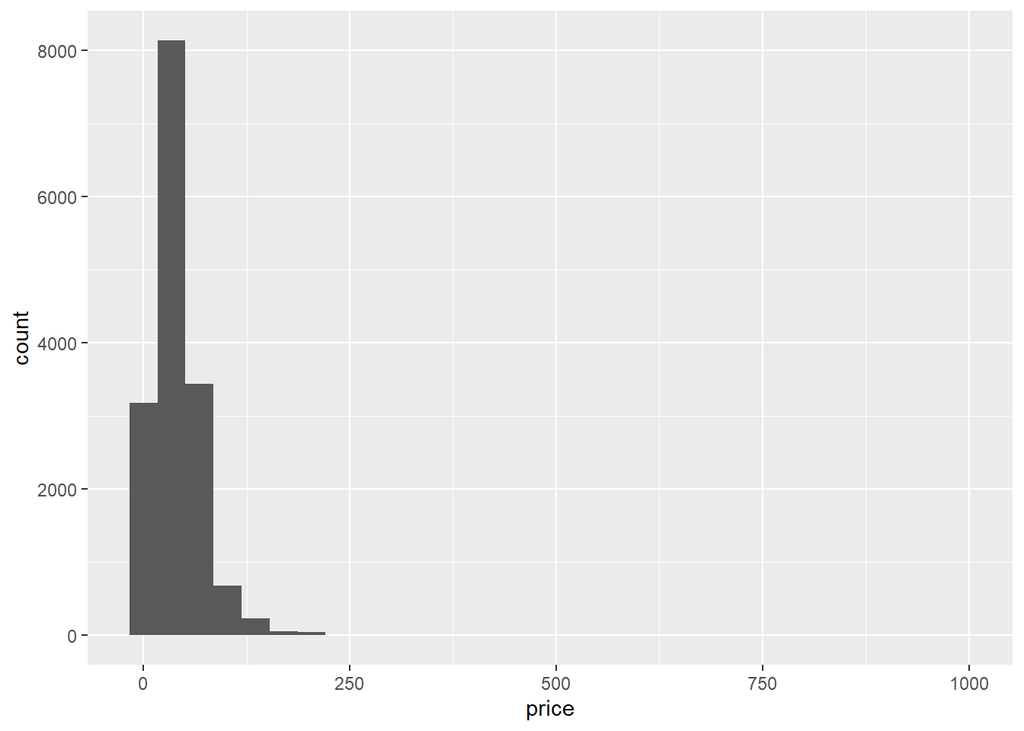

```r
ggplot(data = CSOK, aes(x = price)) +
  geom_histogram()
```

Csudiszép hisztogram. Szebb, mint ami a `hist` függvénnyel kijött eddig, ugye? :)

Ahogy az R output tájékoztatóul írja, a hisztogramhoz 30 db osztályközt (*bin*t) alakított ki az árakból. Ha az osztályközök számát változtatni akarjuk (pl. 20-ra csökkenteni), akkor azt a `geom_histogram` függvény `bins` paraméterével lehet szabályozni:

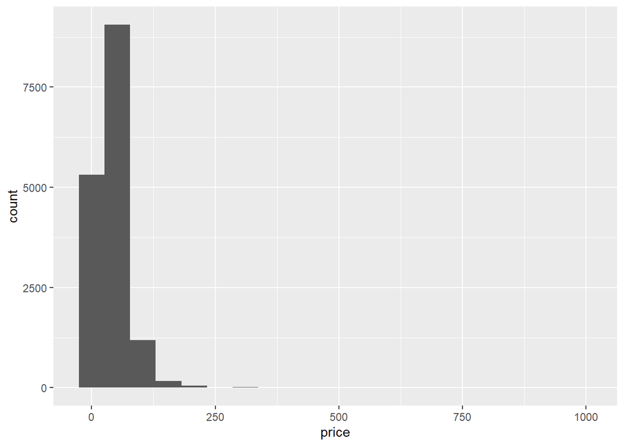

```r
ggplot(data = CSOK, aes(x = price)) +
  geom_histogram(bins = 20)
```

Ha szeretnénk, akkor az osztályköz hozzát változtatni azt is lehet a `geom_histogram` függvény `binwidth` paraméterével.

Ha beszédesebb tengelyfeliratokat vagy egy diagramcímet szeretnénk, akkor azt egy extra *hagyma-rétegben* kell felvinni egy `+` jellel és a `labs()` függvényt használjuk:

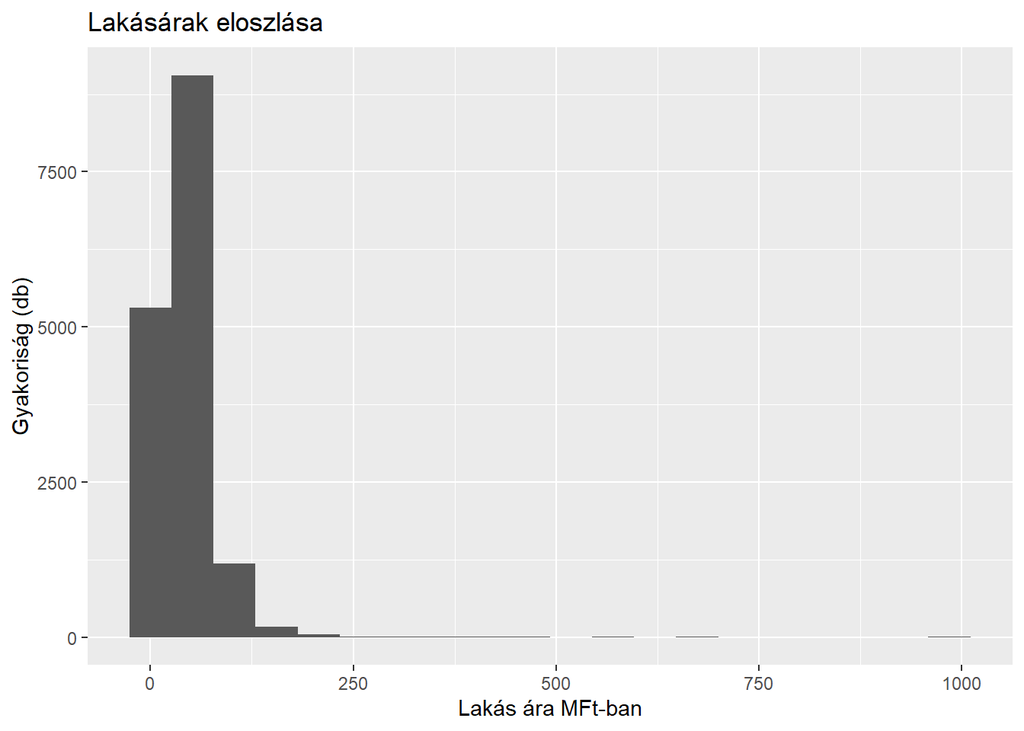

```r
ggplot(data = CSOK, aes(x = price)) +
  geom_histogram(bins = 20) +
  labs(x="Lakás ára MFt-ban", y="Gyakoriság (db)", title = "Lakásárak eloszlása")
```

Igazán remek. Gyönyörködhetünk a lakásárak **jobbra élesen elnyúló** eloszlásában. Ez nem meglepő: logikus eredmény, hogy a legtöbb eladó lakás/ház ára aránylag “*alacsony*”, pár 10 milliós, de van azért 1-2 többszáz milliós luxusvilla a piacon. :)

Mivel a **kapcsolatvizsgálat statisztikai módszerei igen érzékenyek a mennyiségi változókban lévő kilógó értékekre, így keressük meg ezeket doboz-ábrák segítségével az árakban és a területekben**!

### 2.2. Doboz ábra

Csinálhatunk doboz ábrát is `ggplot`tal a lakásárakra. Annyi változtatást kell eszközölni, hogy az *x* tengely helyett az *y* tengelyre kell rakni a vizsgált oszlopunk, mert a doboz ábrán az adatok tengelye ugyebár az *y* és nem az *x* tengely. Plusz az ábra típusát kell cserélni hisztogramról doboz ábrára a második rétegben:

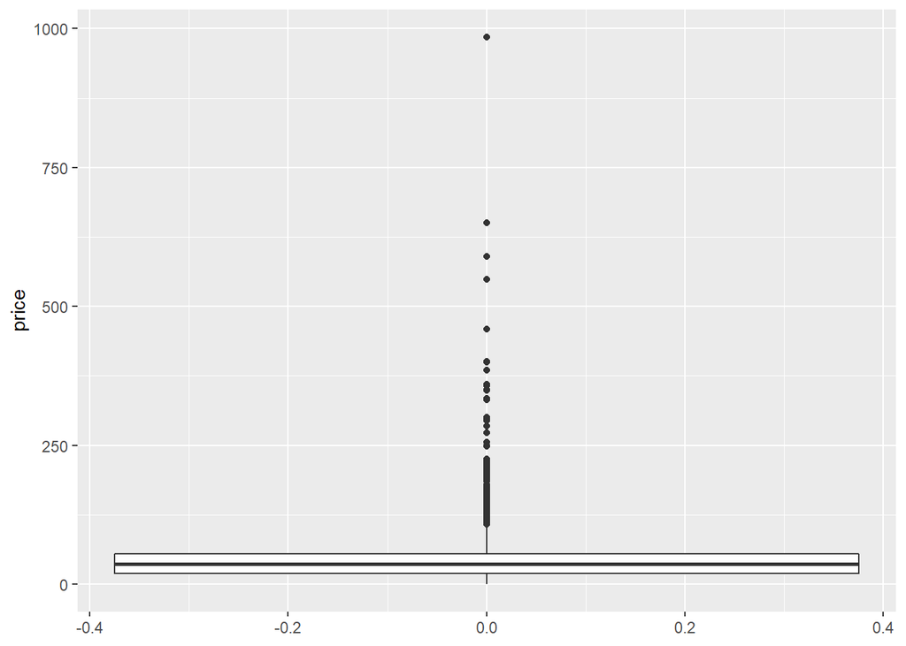

```r
ggplot(data = CSOK, aes(y = price)) +
  geom_boxplot()
```

Ez is csodásan fest! A doboz ábra alapján csak egy ár tűnik igazán kilógónak, azaz nagyon leszakadónak az árak középső 50%-hoz (a dobozhoz) képest: a legnagyobb majdnem 1000 milliós érték.

Szűrjük is ki ezt az egy értéket a `data frame`-ből:

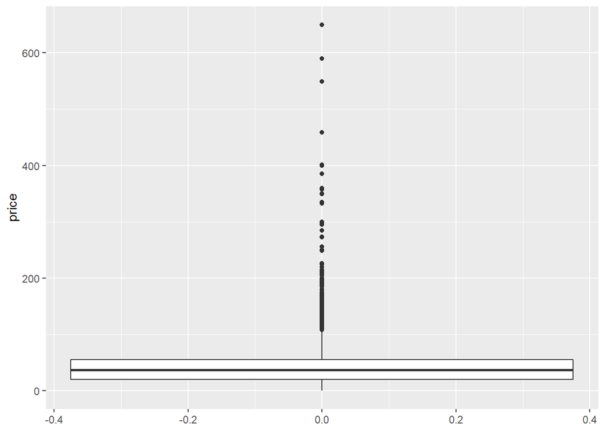

```r
CSOK <- CSOK[CSOK$price < 900,]

ggplot(data = CSOK, aes(y = price)) +
  geom_boxplot()
```

Így már egy kulturáltabb, azaz kevésbé éles jobbra elnyúló áreloszlást mutat a doboz ábra (kitágult a doboz).

Végezzük el az outlier vizsgálatot a területre is:

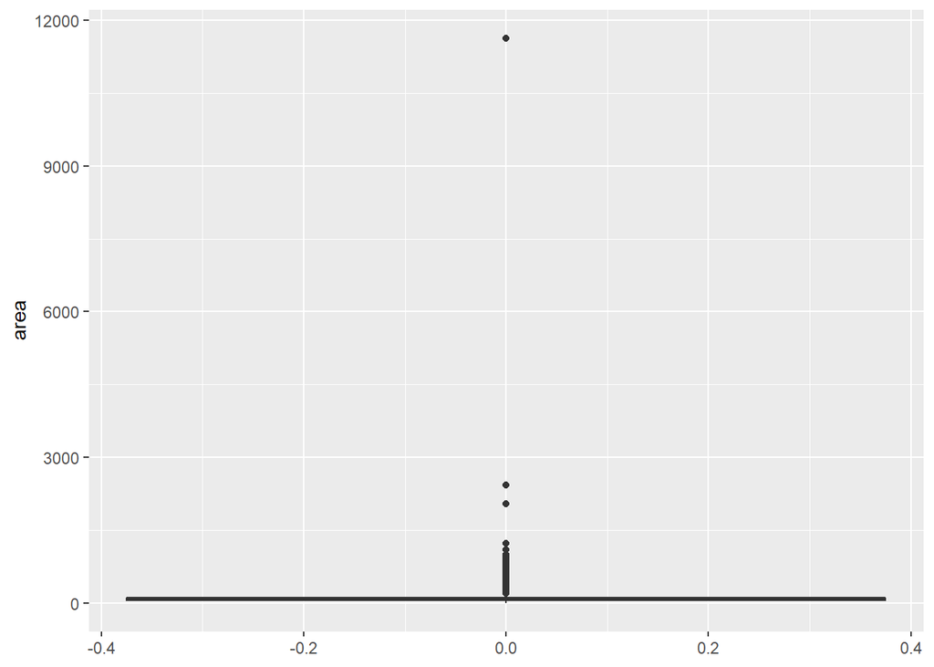

```r
ggplot(data = CSOK, aes(y = area)) +
  geom_boxplot()
```

Tyű, itt több kilógó érték is van! Egy ordító nagy, a legnagyobb 12000 négyzetméteres terület, de a két 2000 négyzetméter feletti pont is elég elszakadónak tűnik már. Nyírjuk ki ezeket a `data frame`-ből:

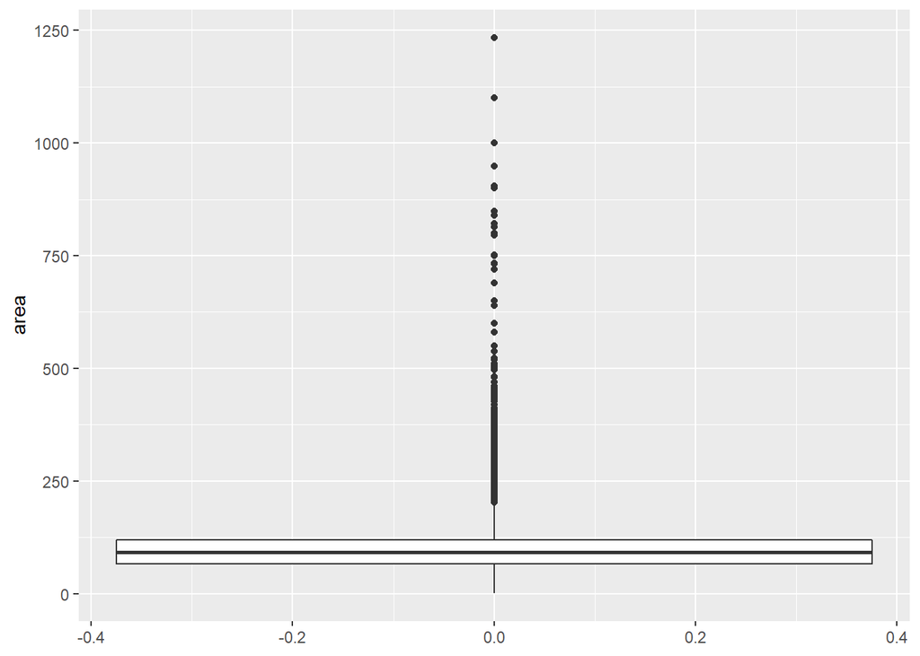

```r
CSOK <- CSOK[CSOK$area < 2000,]

ggplot(data = CSOK, aes(y = area)) +
  geom_boxplot()
```

Na, így már szebb a dolog. Persze a terület is még jobbra elnyúló (a középső 50% = doboz közelebb van a minimumhoz, mint a maximumhoz), de ez is egy természetes jelenség: a legtöbb eladó lakás/ház alacsony területű, és az az 1-2 luxusvilla, aminek az árakban is többszáz milliós értéke volt, annak valószínűleg jó nagy a területe is: kell a hely sertésszaunára meg helikopter leszállópályára. :)

Miután a kilógó értékektől megszabadultunk a mennyiségi változókban lássuk akkor a kapcsolatvizsgálati módszereinket szépen sorban!

## 3. Vegyes kapcsolat

Vizsgáljuk meg azt, hogy milyen kapcsolatban áll a lakásár (*mennyiségi* változó) és az, hogy a házra lehet-e CSOK kedvezményt kapni 3 gyerek után (*minőségi* változó).

A kapcsolat jellegét legjobban egy **csoportosítottdoboz ábrával** lehet leírni: azaz nézzük meg egymást mellett a CSOK-ra jogosult és nem logosult házak/lakások árainak doboz ábráját.

Nézzük meg hogyan lehet itt egy `factor` vagy `logical` típusú változó szerinti csoportosítást megoldani a doboz ábrák szintjén `gpplot2`-ben. Kicsit cselesen, mert itt a kitöltési szín paraméterén (`fill`) keresztül kell jelezni a csoportosítási szándékunkat valamelyik változó szerint az első réteg `aes` függvényének paraméterein belül. Cserébe a gépállat megszínezi nekünk külön színekkel az egyes kerületek ár szerinti doboz ábráit. Ha az *x* tengelyre is beírjuk a minőslgi változónkat, akkor az *x* tengelyre is kiírja annak lehetséges értékeit:

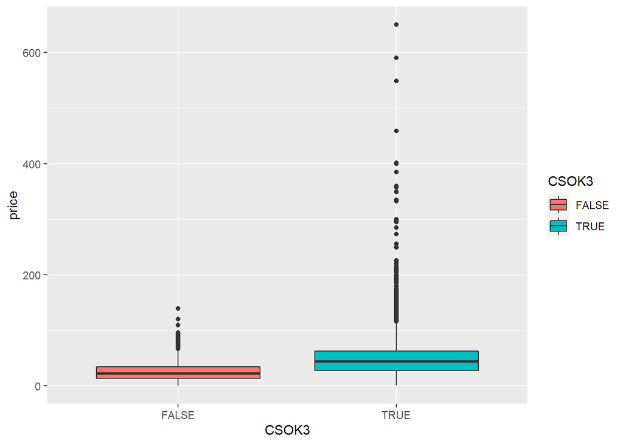

```r
ggplot(data = CSOK, aes(y = price, x=CSOK3, fill = CSOK3)) +
  geom_boxplot()
```

Nagyon szép! Láthatjuk, hogy a CSOK-ra jogosult eladó ingatlanok esetében a medián ár gyakorlatilag annyi, mint a nem CSOK-os ingatlanok esetén az árak felső kvartilise! Plusz, a legangyobb, enyhén felfelé kilógó árak is a CSOK-ra jogosult ingatlanok körébe tartoznak.  
Ez talán nem meglepő: a rendes 3 gyerekkel tervező nagycsalásoknak kell a tér és a jól felszerelt, drága lakás!

Tehát a kapcsolat jellege tekintetében elmondhatjuk, hogy a CSOK-os lakások középső 50% tekintetében is egy magasabb árszínvonalat képviselnek és ide koncentrálódnak a felfelé kilógó értékek is.

De kérdés, hogy mennyire erős ez a kapcsolat? **Hány százalékban magyarázza mégis a CSOK kedvezmény a lakásárak ingadozását?** Erre a kérdésre adja meg a választ a **variancia-hányados** becenevű statisztikai mutató.

### 3.1. A variancia-hányados

A variancia-hányados számolásához szükséges dolgokat az R `aov` függvénye adja meg. Egyszerűen rá kell ereszteni a függvényt a mennyiségi és minőségi változóra **hullámjelekkel elválasztva**: *mennyiségi változó ~ minőségi változó* –> a sorrend számít! Elül van mindig a mennyiségi változó neve hátul a minőségi változó neve! Itt nem muszáj a változók nevére `$` jellel hivatkozni a `data frame`-n keresztül. A vizsgált két változót tartalmazó `data frame` objektum nevét meg lehet adni a függvény `data` paraméterében:

```r
aov(price ~ CSOK3, data = CSOK)
```

```
## Call:
##    aov(formula = price ~ CSOK3, data = CSOK)
##
## Terms:
##                    CSOK3 Residuals
## Sum of Squares   1956779  13970044
## Deg. of Freedom        1     15794
##
## Residual standard error: 29.74081
## Estimated effects may be unbalanced
```

Az eredmények két fontos **négyzetösszeg** (in inglis *Sum of Squares*) mutatót adnak meg:

- **Sum of Squares Between = $SSB$**: A **minőségi változó csoportátlagainak** összes négyzetes **eltérése a mennyiségi változó főátlagától**.
- Esetünkben most $SSB=1956779$
- **Sum of Squares Residuals = $SSR$**: Az egyes **megfigyelések** mennyiségi változó szerinti összes négyzetes **eltérése saját minőségi változó csoportjuk átlagtól**.
- Esetünkben most $SSR=13970044$
- A két érték összege a **Sum of Squares Total = $SST=SSB+SSR$**: Ez nem más, mint a mennyiségi változó varianciájának “*teteje*”, az egyes **megfigyelések** összes négyzetes **eltérése a mennyiségi változó főátlagától**.
  - Esetünkben most $SST=1956779+13970044=15926823$

Az összefüggést a mennyiségi változó varianciájával (szórásnégyzetével) könnyen ellenőrizni tudjuk:

```r
sd(CSOK$price)^2 * (nrow(CSOK)-1)
```

```
## [1] 15926823
```

Vizuálisan gondolva erre a jelenségre azt mondhatjuk, hogy az egyes $SS$ mutatók az alábbi **távolságok** négyzetes összegét jelentik. A négyzetre emelésre a távolságok *eltérő előjelének kiküszöbölése* miatt van szükség (mint a szórásképlet kapcsán néztük):

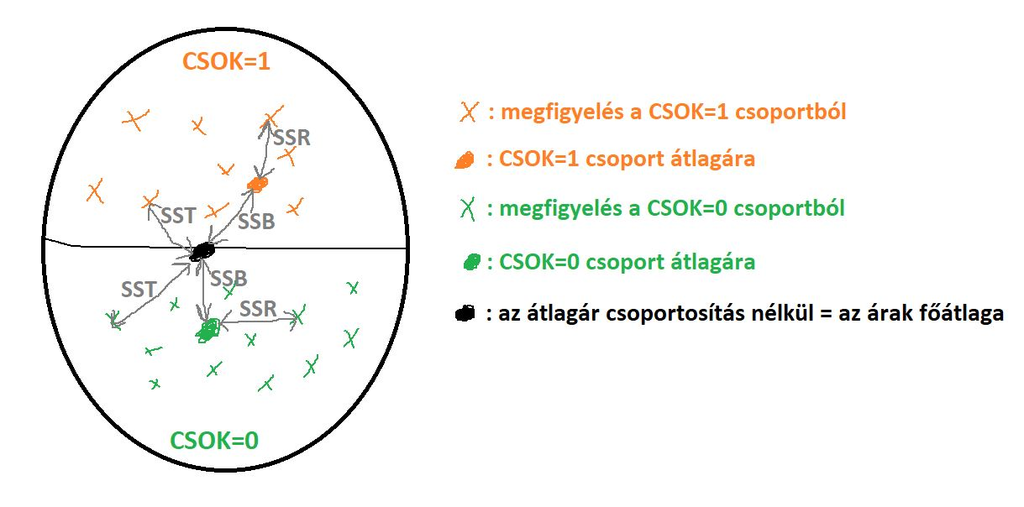

Tehát vizuálisan a következőképp érdemes gondolni a különböző $SS$-ekre:

- $SSR$: Megfigyelések távolsága saját csoportjuk átlagától
- $SSB$: Csoportátlag távolsága a főátlagtól
- $SST$: Megfigyelések távolsága a főátlagától

Ezek alapján nekünk az a jó a csoportosítás, azaz a minőségi magyarázóváltozó magyarázóereje szempontjából, ha **fix** $SST$ mellett $SSB$ **nagy** és $SSR$ **kicsi**. Mert ekkor a **csoportátlagok messze vannak** a főátlagtól és így implicite **egymástól** is, míg a csoportátlagtól az egyes **megfigyelések nagyon kis mértékben térnek csak el saját csoportátlaguktól**:

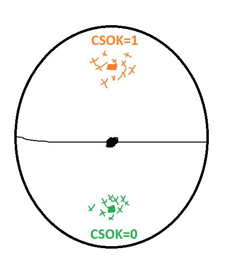

Ebben az esetben, ahogy az ábráról is látszik a csoportosításunk, azaz a minőségi változónk magyarázóereje nagy! Tehát az kell nekünk, hogy az $SST$ minél nagyobb részét tegye ki $SSB$, azaz, hogy **az $\frac{SSB}{SST}$ hányados nagy legyen**! Ez a mutató pedig a **variancia-hányados**, és a most elvégzett módszer neve a **variancia-analízis, azaz ANOVA = ANalysis Of VAriances**.

Mivel $SST=SSB+SSR$, így a $\frac{SSB}{SST}$ variancia-hányados biztos, hogy $0-1$ közötti, és **százalékosan** is értelmezhető, hiszen $SSB$ része $SST$-nek. Ez alapján nekünk most:

$\frac{SSB}{SST} = \frac{1956779}{1956779+13970044}=0.1228606=12.3\%$ –> **A CSOK jogosultság az ingatlanárak alakulásának (varianciájának) 12.3%-át magyarázza a megfigyelt mintában!** Ez egy **enyhén közepes magyarázóerő**, mivel a variancia-hányadost a következőképpen “*korszakoljuk*”:

- **variancia-hányados < 10% –> gyenge kapcsolat**
- **10% <= variancia-hányados <= 50% –> közepes kapcsolat**
- **variancia-hányados > 50% –> erős/szoros kapcsolat**

Szokás értelmezni a vegyes kapcsolat erősségét a variancia-hányados **gyökével**, a **szórás-hányadossal** is. Ez szintén $0-1$ közti mutató, de már **százalékosan NEM értelmezhető**. Mivel a gyökvonás után nem lesz az igaz, hogy $\sqrt{SSB}$ része $\sqrt{SST}$-nek, hiszen tagonként nem lehet gyököt vonni, azaz $\sqrt{SSB+SSR}\neq\sqrt{SSB}+\sqrt{SSR}$  
Emiatt a “*korszakolási határok*” is gyök alá kerülnek: $\sqrt{0.5}\approx0.7$ és $\sqrt{0.1}\approx0.3$. azért nem vesszük a gyökvonást pontosabban, hogy szórás-hányadosra is “*szép*” számokat kapjunk határoknak:

- **szórás-hányados < 0.3 –> gyenge kapcsolat**
- **0.3 <= szórás-hányados <= 0.7 –> közepes kapcsolat**
- **szórás-hányados > 0.7 –> erős/szoros kapcsolat**

Láthatjuk, hogy $\sqrt{0.123}=0.3507$, tehát a *CSOK - Ár* kapcsolat továbbra is küzepes erősségű marad.

### 3.2. Az F-próba vegyes kapcsolatra

A **variancia- és szórás-hányadosok a kapcsolat erejét csupán a megfigyelt mintán belül írják le!** Kell egy **hipotézisvizsgálat annak eldöntésére, hogy a megfigyelt kapcsolat általánosítható-e az ingatlanok sokaságára**, azaz a megfigyelt mintán kívüli világra. Ez a hipotézisvizsgálat az **ANOVA** vagy **F-próba**.

A próba hipotézisei a következők:

- $H_0:$ A kapcsolat a sokaságban nem szignifikáns, azaz **variancia-hányados = 0 a sokaságban**
- $H_1:$ A kapcsolat a sokaságban szignifikáns, azaz **variancia-hányados > 0 a sokaságban**

Tehát, ebben az esetben $H_1$-nek szurkolunk, mert az állítja azt, hogy a variancia-hányados, azaz a kapcsolat magyarázóereje nem csupán a mintavételi hiba miatt nem nulla az összes magyar ingatlan sokaságában.

A próbának sajnos egy súlyos **előfeltétele, hogy a mennyiségi változó a kapcsolatban mindig legyen normális eloszlású változó**. Hát, ez most a lakásárakra a jobbra elnyúló hisztogram alapján bajosan teljesül:

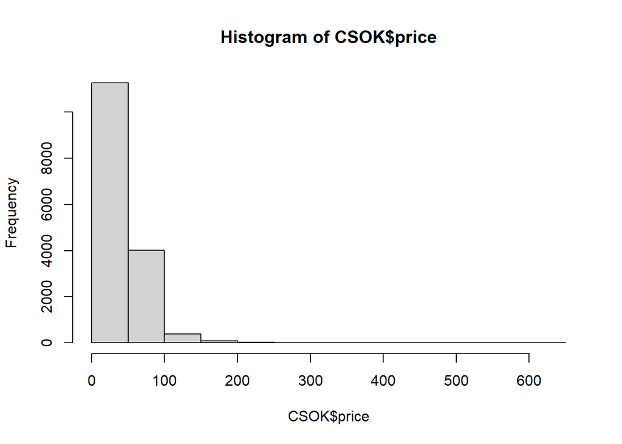

```r
hist(CSOK$price)
```

De ha veszem a logaritmusát kicsit szimmetrikusabbá tudom tenni az árak eloszlását:

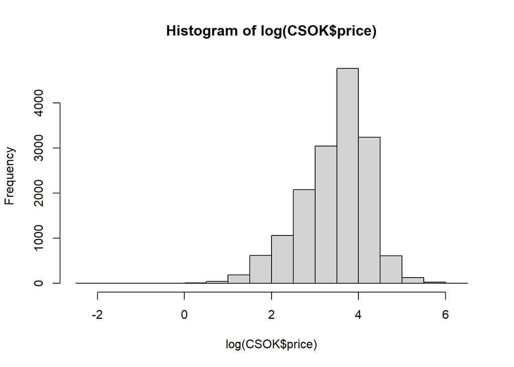

```r
hist(log(CSOK$price))
```

Most a kis értékek közül van pár, aminek kimondottan kicsi a többi értékhez a gyakorisága, tehát kicsit balra elnyúló ez a logaritmizált eloszlás is, de enyhébb az aszimmetria, mint a jobbra elnyúló esetben volt. Számoltassunk akkor hát p-értéket úgy, hogy az árak logaritmálva vannak. Feleslegese is vizsgálni a dolgot Shapiro-Wilk-próbával: az enyhe balra elnyúlás miatt úgyis $H_1$ lesz elfogadva.

Ez van, sajnos jobban nem tudjuk kielégíteni ezt a normalitás feltételt.

Ezen kívül az **F-próba azt is felteszi, hogy a mennyiségi változónk szórásai a minőségi változó csoportjai szerint azonosnak vehetők a sokaságban**.  
Ezt egy úgynevezett **Levene-próbával tudjuk ellenőrizni**. A próbában a $H_0$, hogy a **szórások azonosak**, a $H_1$ pedig az, hogy **van legalább egy eltérő szórású csoport**.  
R-ben a próba p-értékét a `levene.test` függvénnyel lehet kiszámolni, ami a `lawstat` csomagban lakik. Telepítsuk és hivatkozzuk is be a csomagot:

```r
install.packages("lawstat")
library(lawstat) # Szokásos módon ne törődjünk az esetleges Warningokkal! :)
```

Majd használjuk a csomag `levene.test` függvényét. Első paraméter a mennyiségi változó, aminek a szórásait vizsgáljuk (ez most az árak logaritmusa, hiszen a normalitás miatt az fog az F-próbába is menni), második paraméter a minőségi változó, aminek értékei szerint csoportosítjuk a szórásokat:

```r
levene.test(log(CSOK$price), CSOK$CSOK3)
```

```
##
##  Modified robust Brown-Forsythe Levene-type test based on the absolute
##  deviations from the median
##
## data:  log(CSOK$price)
## Test Statistic = 5.5987, p-value = 0.01799
```

Az eredmény alapján a **p-érték = $0.018=1.8\%$**. Ez azt jelenti, hogy $\alpha=1\%$ mellett $H_0$-t, míg $\alpha=5\%$ mellett már $H_1$-et kell elfogadni. Azaz a **döntés nem stabil**, hiszen nagyon függ $\alpha$ megválasztásától. A korrekt megoldás az, hogy nagyobb mintát kéne venni, amíg a p-érték stabilan $1\%$ alá vagy $10\%$ fölé nem kerül, de ezt nem tudjuk kivitelezni.  
Az $1\%-10\%$ közti úton a p-érték az $1\%$-hoz van közelebb, azaz valószínűbbnek tűnik a $H_1$ igazsága, mint a $H_0$-é, tehát **esélyesebb, hogy az egyező CSOK-jogosultság szerinti szórások feltétele nem teljesül**. De nem is sikerült egyértelműen elutasítani a feltétel $H_0$-ját, szóval “*recsegve-ropogva*”, mint a az árak normalitásánál, de továbbmegyünk az **F-próva p-értékének kiszámításához azzal a megjegyzéssel, hogy a p-érték számoláshoz szükséges előfeltételek nem a legszebben teljesülnek**.

Szerencsére csak annyi a titok nyitja az F-próba p-értékéhez, hogy a korábban használt `aov` függvény eredményét kell még beleágyazni egy `summary` függvénybe:

```r
summary(aov(log(price) ~ CSOK3, data = CSOK))
```

```
##                Df Sum Sq Mean Sq F value Pr(>F)
## CSOK3           1   1494  1493.6    2861 <2e-16 ***
## Residuals   15794   8244     0.5
## ---
## Signif. codes:  0 '***' 0.001 '**' 0.01 '*' 0.05 '.' 0.1 ' ' 1
```

Itt is leolvashatjuk a `Sum Sq` oszlopban az $SS$ mutatóink értékét, és a jobb szélen a `Pr(>F)` oszlopan van egy p-érték is.

Az eredmény alapján a **p-érték kisebb, mint $2\times10^{-16}$**. Ez kisebb még a legkisebb szokásos szignifikancia-szintnél, az $\alpha=1\%$-nál is, így egyértelműen és stabilan elfogadható a $H_1$, ami szerint a CSOK jogosultság magyarázóereje az árakra nézve szignifikánsan több a sokaságban is, mint 0.  
Azaz a **a magyarázóerő NEM a mintavételi hiba műve**.

**Figyelem!** Ilyen 0 közeli p-érték simán kijöhet $10\%$ alatti p-érték esetén is! Ez azt jelenti, hogy az a **gyenge magyarázóerő, amit a mintában értünk általánosítható a mintán kívüli világra is**. Tehát a kapcsolat a sokaságban is megvan. Szóval ilyen **csak a kis p-érték alapján NE mondjuk soha, hogy a kapcsolat erős, mert a p-érték NEM ezt méri!!!** Hanem azt mutatja meg, hogy a **mintában megfigyelt kapcsolat,a minek erősségét a variancia-hányados mutatja ki általánosítható-e a mintán kívüli világra, vagy sem!!!**

Mindenesetre, végkövetkeztetésül azt mondhatjuk el, hogy **a magyar inngatlanpiacon van egy közepes erősségű és az ingatlanok sokaságában is szignifikáns, $12.3\%$-os, közepes magyarázóerejű áremelő hatása annak, ha egy lakás CSOK kedvezményre jogosult**.

## 4. Asszociációs kapcsolat

Vizsgáljuk meg azt, hogy milyen kapcsolatban áll a lakás településének típusa, a `Settlement` (*minőségi* változó) és az, hogy a házra lehet-e CSOK kedvezményt kapni 3 gyerek után (*minőségi* változó).

A kapcsolat jellegét legjobban egy **halmozott oszlop** diagrammal lehet leírni. Ez megmutatja, hogy az egyik minőségi változó kategóriáin (értékein) belül hogyan oszlanak meg a másik minőségi változó kategóriái (értékei).

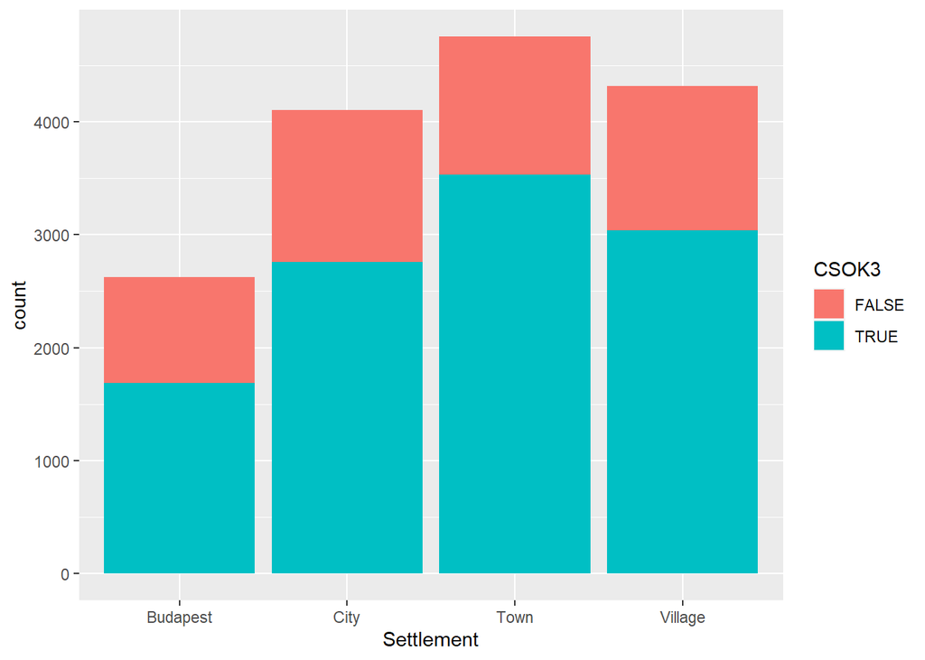

```r
ggplot(data = CSOK, aes(x = Settlement, fill = CSOK3)) + # y tengely üres, alapból a gyakoriságok kerülnek rá
  geom_bar() # ez az általános oszlopdiagram: vegyük észre, hogy ez külön ábratípus a hisztogramhoz képest!!
```

Az ábráról láthatjuk, hogy a legtöbb ingatlant kisvárosokban (*Town*) kínálják eladásra, míg a legkevesebbet a fővárosban, Budapesten. Érzésre azt mondanánk, hogy a CSOK-ra jogosult ingatlanok legnagyobb arányban a kisvárosokban (*Town*) fordulnak elő és Budapesten a legkevésbé, de ezen arányok összehasonlítását így szemmelveréssel nehézzé teszi, hogy az egyes településítpusok oszlopai eltérő méretűek. Hiszen pl. a *Town* kategóriában *azért is van darabra olyan sok CSOK-ra jogosult ingatlan, mert eleve ott van a legtöbb ingatlan*.

Szóval valahogy jó lenne **100%-ig halmozott oszlop** diagrammá alakítani a fenti ábrát, hogy lássuk egyes településtípsok szerint a CSOK-ra jogosult ingatlanok **arányát**. Ezt az átalakítást a `geom_bar` függvény `position` paraméterének `"fill"`-ra állításával érhetjük el:

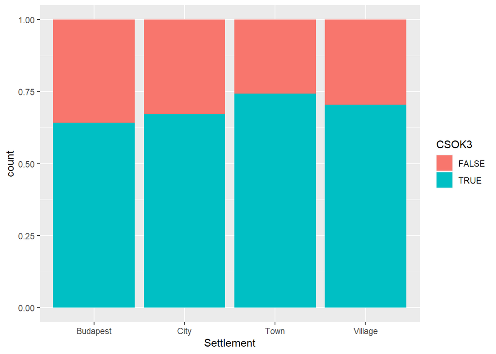

```r
ggplot(data = CSOK, aes(x = Settlement, fill = CSOK3)) +
  geom_bar(position = "fill")
```

Így már látszik is, hogy az előbbi ábrán a szemmel megérzett dolgok tényleg bejöttek. De itt már egyértelműbben látszik, hogy a **legkisebb arányban Budapesten vannak CSOK-ra jogosult ingatlanok és a legnagyobb arányban a kisvárosokban (Town)**. Ez tehát a két változó közti **kapcsolat jellege**.

Nézzük meg hogyan lehet a színezést mondjuk egy másik színpalettáról megoldani! Egy új réteg hozzáadásával lehet szabályozni, hogy az `aes` függvényben megadott `fill` színpalettáját:

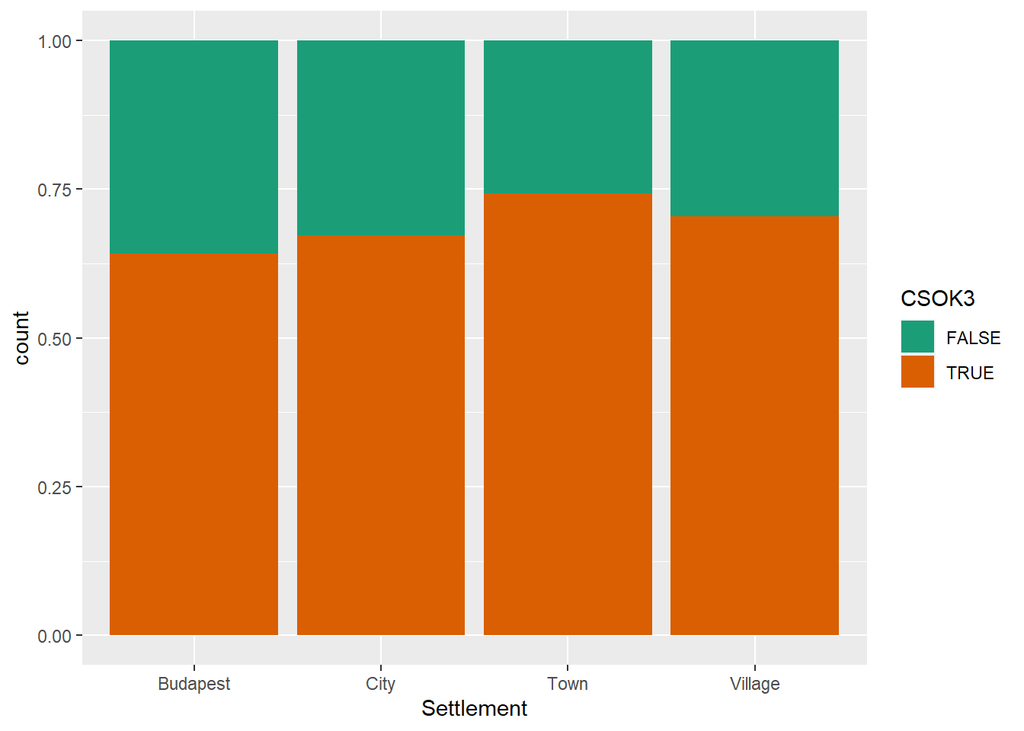

```r
ggplot(data = CSOK, aes(x = Settlement, fill = CSOK3)) +
  geom_bar(position = "fill") +
  scale_fill_brewer(palette="Dark2") # az új, színkitöltést (fill) szabályozó réteg
```

Csudiszép sötét tónusú színeink lettek a halmozáshoz! :) A színpalettákról, és a színváltoztatás még bővebb rejtelmeiről `ggplot2`-ben [ezen](http://www.sthda.com/english/wiki/ggplot2-colors-how-to-change-colors-automatically-and-manually) a linken mélyebben is olvashatsz.

Megnézhetjük a diagram mögötti **kétváltozós gyakorisági táblázat** (leánykori nevén *kereszttábla* vagy *kontingencia tábla*) tényleges gyakoriság adatait is. Ehhez egy ismerős függvényt, a `table`-t kell alkalmazni a két vizsgált nominális változóra:

```r
table(CSOK[,c("Settlement", "CSOK3")])
```

```
##           CSOK3
## Settlement FALSE TRUE
##   Budapest   941 1685
##   City      1343 2757
##   Town      1224 3529
##   Village   1276 3041
```

A táblából látszik, hogy *1685* darab budapesti és CSOK-ra jogosultingatlan található a táblában.

A `prop.table` bevetésével az arányok is ismét lekérdezhetők:

```r
round(prop.table(table(CSOK[,c("Settlement", "CSOK3")]))*100, 1)
```

```
##           CSOK3
## Settlement FALSE TRUE
##   Budapest   6.0 10.7
##   City       8.5 17.5
##   Town       7.7 22.3
##   Village    8.1 19.3
```

A kisvárosokban (*Town*) lévő CSOK-ra jogosult lakások aránya a tábla teljes elemszámhoz képest 22.3%.

De itt már lekérhetjük az úgynevezett **peremeloszlásokat** is! Pl. ha külön szeretnénk megnézni a budapesti ingatlanokon **belül** a CSOK-ra jogosultak arányát:

```r
round(prop.table(table(CSOK[,c("Settlement", "CSOK3")]), 1)*100, 1)
```

```
##           CSOK3
## Settlement FALSE TRUE
##   Budapest  35.8 64.2
##   City      32.8 67.2
##   Town      25.8 74.2
##   Village   29.6 70.4
```

Budapesten a CSOK-ra jogosult ingatlanok aránya 64.2%, míg kisvárosokban (*Town*) már 10 %-ponttal magasabb, 74.2%.

A `prop.table` függvény **második paraméter**ében lévő $1$ adta meg, hogy az **arányosítást** a sorrendben először átadott változó, azaz a **Settlement részösszegei szerint** nézzük.

### 4.1. A Cramer-együtható

A két minőségi változó **kapcsolatának szorosság**át egy **Cramer-együttható** néven futó mutatószámmal tudjuk mérni.

A számolás alapötlete, hogy a fentebb, a `table` függvénnyel létrehozott kétváltozós gyakorisági táblából legyárt egy olyan verziót, hogy a *kapcsolat teljes hiánya, azaz függetlenség* esetén ez hogy *nézne* ki. Tehát pl. kiszámolja azt, hogy hány budapesti CSOK-ra jogosult lakás lenne, ha a két változó 0%-ban magyarázná egymást.  
Majd a függetlenség esetén fennálló elvi és a fentebb kiszámolt valós gyakorisági táblák **távolságát méri ez a Cramer mutató egy $0-1$ közötti skálán**. Maga a mutató tehát $0-1$ közötti, de **NEM értelmezzük százalékban**, mivel a műveletei között van egy *gyökvonás*, így a **szórás-hányadossal összemérhető mutató**.

Ennek megfelelően a **Cramer-együttható értelmezési határai az alábbiak**:

- **Cramer < 0.3 –> gyenge kapcsolat**
- **0.3 <= Cramer <= 0.7 –> közepes kapcsolat**
- **Cramer > 0.7 –> erős/szoros kapcsolat**

A mutatót számolni R-ben a `questionr` csomag `cramer.v` függvényével lehet. Telepítsük is a csomagot és hivatkozzuk be a függvényeit R-be:

```r
install.packages("questionr")
library(questionr) # Szokásos módon ne törődjünk az esetleges Warningokkal! :)
```

Eresszük is rá rögtön a `cramer.v` függvényt a **Settlement** és **CSOK3** minőségi változókból a `table` függvénnyel készült **kereszttáblára**.

```r
cramer.v(table(CSOK[,c("Settlement", "CSOK3")]))
```

```
## [1] 0.07856072
```

Az eredményül kapott $0.0786$-ra kerekítható érték **gyenge erősségű** kapcsolatot mutat a két minőségi változónkra a *fentebb megadott értékhatárok szerint*. Tehát annyira nem erős összefüggés az, amit kimutattunk a halmozott oszlopdiagrammal, hogy jellemzően a kisvárosokban (*Town*) vannak a CSOK-ra jogosult ingatlanok.

### 4.2. A Khi-négyzet próba

A variancia-hányadoshoz hasonlóan, a **Cramer-együttható is csak a megfigyelt mintában írja le a kapcsolat szorosságát, de a megfigyelt lakásokon kívüli világról nem mond semmit**.

Ide is kell egy **hipotézisvizsgálat annak eldöntésére, hogy a megfigyelt kapcsolat általánosítható-e az ingatlanok sokaságára**, azaz a megfigyelt mintán kívüli világra. Ez a hipotézisvizsgálat a **Khi-négyzet próba** vagy $\chi^2$-próba. A $\chi$ a “*Khi*” görög betű szimbóluma.

A próba hipotézisei a következők:

- $H_0:$ A kapcsolat a sokaságban nem szignifikáns, azaz **Cramer-együttható = 0 a sokaságban**
- $H_1:$ A kapcsolat a sokaságban szignifikáns, azaz **Cramer-együttható > 0 a sokaságban**

Tehát, ebben az esetben $H_1$-nek szurkolunk, mert az állítja azt, hogy a Cramer-együttható, azaz a kapcsolat magyarázóereje nem csupán a mintavételi hiba miatt nem nulla az összes magyar ingatlan sokaságában.

A próba elvégzésének előfeltétele, hogy a két minőségi változó szerinti gyakorisági táblában minden érték legyen **legalább 5**.

Gyorsan ellenőrizhető, hogy ezt a feltételt teljesítjük:

```r
table(CSOK[,c("Settlement", "CSOK3")])
```

```
##           CSOK3
## Settlement FALSE TRUE
##   Budapest   941 1685
##   City      1343 2757
##   Town      1224 3529
##   Village   1276 3041
```

A hipotézisvizsgálathoz p-értéket a `chisq.test` függvénnyel kapunk, amit a kétdimenziós gyakorisági táblára kell ráengedni, mint ahogy a `cramer.v` függvényt is kellett.

```r
chisq.test(table(CSOK[,c("Settlement", "CSOK3")]))
```

```
##
##  Pearson's Chi-squared test
##
## data:  table(CSOK[, c("Settlement", "CSOK3")])
## X-squared = 97.49, df = 3, p-value < 2.2e-16
```

Az eredmény alapján a **p-érték kisebb, mint $2\times10^{-16}$**. Ez kisebb még a legkisebb szokásos szignifikancia-szintnél, az $\alpha=1\%$-nál is, így egyértelműen és stabilan elfogadható a $H_1$, ami szerint a településtípus (*Settlement*) magyarázóereje a CSOK jogosultság nézve szignifikánsan több a sokaságban is, mint 0.  
Azaz a **a magyarázóerő NEM a mintavételi hiba műve**.

**Figyelem!** Attól, hogy a magyarázóerő szignifikáns hatással bír a sokaságban, attól az még egy **gyenge magyarázóerő** a Cramer-együttható alapján.

Tehát, azt mondja az eredmény, hogy azt **a gyenge erősségű kapcsolatot lehet kiálítalánosítani a lakások sokaságára is a mintából, ami szerint a CSOK-ra jogosult lakások leginkább a kisvárosokra** (*Town*) és **legkevésbé Budapestre jellemzők**.

## 5. Korrelációs kapcsolat

Most egy picit váltsunk adatbázist és olvassuk be a Moodle-n található PreventableMortality_Eurostat.xlsx című fájlt. Ebben az adattáblában az EU $30$ országáról található $4$ változó. Az adatok forrása az [Eurostat](https://ec.europa.eu/eurostat/web/health/overview):

- **Country**: Az ország neve
- **Smokers**: Az országban a dohányzó népesség aránya (%)
- **HealthExp**: Az ország egészségügyi kiadásai a GDP %-ban
- **PreventableMortality**: 100 ezer főre jutó halálozások száma az országban 75 éves kor alatti megelőzhető betegségekből (pl. tüdőrák, alkohol okozta intoxikáció, szívroham)

Olvassuk is be a fájl tartalmát egy **Mort** nevű `data frame`-be a `readxl` csomag segítségével:

```r
library(readxl)
Mort <- read_excel("PreventableMortality_Eurostat.xlsx")
str(Mort)
```

```
## tibble [30 × 4] (S3: tbl_df/tbl/data.frame)
##  $ Country             : chr [1:30] "Hungary" "Latvia" "Romania" "Lithuania" ...
##  $ Smokers             : num [1:30] 25.8 24.1 19.8 20.2 22.7 22.6 24.5 27.3 21.9 21.2 ...
##  $ HealthExp           : num [1:30] 6.79 6.01 5.15 6.47 6.39 ...
##  $ PreventableMortality: num [1:30] 327 322 305 303 247 ...
```

Szuper, megvan mind a $30$ ország, mind a $4$ változóval! Láthatjuk, hogy igazából a **Country** kivételével (ami amúgy is csak az azonosító szerepét játsza a táblában) minden változónk *mennyiségi változó*, azaz numerikus adat.

Ez azt jelenti, hogy ha meg akarjuk tudni, hogy a megelőzhető halálokokból származó halálozást egy országban a népesség általános egészségi állapota (ami leírható a dohányzók arányával) vagy az egészségügyi kiadások mértéke magyarázza jobban, akkor **korrelációs kapcsolatvizsgálat**ot kell végeznünk!

A korrelációs kapcsolatvizsgálat legfontosabb mutatója nem meglepő módon egy **korreláció** nevű mutatószám, amit $r$-el jelölünk!  
Ez a mutatószám **két mennyiségi változó kapcsolatát egy $[-1,+1]$ skálán írja le**, azaz $-1 \leq r \leq +1$.

Számolni R-ben könnyen lehet, csak a `cor` névre hallgató függvényt kell ráreszteni a két vizsgált változóra.

```r
cor(Mort$PreventableMortality, Mort$HealthExp)
```

```
## [1] -0.6232231
```

```r
cor(Mort$PreventableMortality, Mort$Smokers)
```

```
## [1] 0.4947717
```

Láthatjuk, hogy a két vizsgált korrelációs kapcsolatra két **eltérő előjelű** korrelációt kaptunk.  
Ez fontos infó, mivel a **korreláció előjele mutatja meg a kapcsolat irányát**:

- **Pozitív** korreláció: **egyirányú kapcsolat** a két változó között. Ha nő az egyik, akkor várhatóan nő a másik is.
- **Negatív** korreláció: **ellentétes kapcsolat** a két változó között. Ha nő az egyik, akkor várhatóan csökken a másik.

Ez alapján azt mondhatjuk el, hogy a negatív előjel miatt az egészégügyi kiadások között ellentétes irányú kapcsolat van: ha nőnek az egészségügyi kiadások a GDP %-ban, akkor várhatóan csökken a megelőzhető okokból származó halálozás 100 ezer főre. Ez az ellentétes irányú mozgás logikus, ilyesmire számítottunk.

A dohányzó népesség aránya és a megelőzhető halálozás közti pozitív korreláció is logikus, hiszen ez azt mondja, hogy a dohányzó népesség arányának növekedésével várhatóan a megelőzhető halálozás növekedése is együttjár.

Az előjel értelmezése után a következő dolog, amire ránézünk az a **korreláció abszolút értéke**. Ugyanis ez írja le a két változó közti kapcsolat közötti **kapcsolat erősségét/szorosságát**. Mivel ez az abszolút érték alapvetően egy $[-1,+1]$ intervallumon értelmezett mutatószámból képződött meg, így **NEM értelmezhető százalékosan**!! Hiába eredményez az abszolút érték művelet egy $0-1$ közötti értéket!  
Azaz, a korreláció abszolút értékének értelmezési határai a **Cramer-együtthatóval és a szórás-hányadossal rokoníthatók**:

- **$|r|$ < 0.3 –> gyenge kapcsolat**
- **0.3 <= $|r|$ <= 0.7 –> közepes kapcsolat**
- **$|r|$ > 0.7 –> erős/szoros kapcsolat**

Tehát, azt mondhatjuk, hogy **az egészségügyi kiadások és a megelezőzhető halálozás közti kapcsolat ellentétes irányú és közepes erősségű**. Míg a **dohányzók aránya és a megelőzhető halálozás közti kapcsolat egyirányú** és szintén **közepes erősségű**.

### 5.1. A determinációs együttható

Ugyanakkor, minden további nélkül **négyzetre lehet emelni a korrelációt**, és akkor megkapjuk a **determinációs együttható** című mutatószámot, amit szokás csak a számolási módból adódóan **R-négyzet** mutatónak is hívni: $R^2=r^2$

A négyzetre emelés miatt ez a mutatószám alapból a $0-1$ intervallumon értelmezett, és így **szazalékosan értelmezhető**, azaz a **variancia-hányadossal rokonítható**.  
Ennek megfelelően a **determinációs együttható értelmezési határai** is a variancia-hányadosnak megfelelően alakulnak:

- **$R^2$ < 10% –> gyenge kapcsolat**
- **10% <= $R^2$ <= 50% –> közepes kapcsolat**
- **$R^2$ > 50% –> erős/szoros kapcsolat**

Mivel mindkét korrelációnk abszolút értékben $0.3$ és $0.7$ közé esett, így mindkét kapcsolatunk **közepes erősségűnek** mondható, de a **magasabb korreláció abszolút érték miatt azt mondhatjuk, hogy a megelőzhető halálozás szorosabb kapcsolatban áll az egészségügyi kiadásokkal, mint a dohányzó népesség arányával**.  
Ezt megerősíti a determinációs együttható is, ha kiszámoljuk őket egy négyzetre emeléssel:

```r
cor(Mort$PreventableMortality, Mort$HealthExp)^2
```

```
## [1] 0.3884071
```

```r
cor(Mort$PreventableMortality, Mort$Smokers)^2
```

```
## [1] 0.2447991
```

Az értékeket úgy is értelmezhetjük, hogy a dohányzó népességaránya kb. $24\%$-ban magyarázza a megelőzhető halálozások számának alakulását, míg az egészségügyi kiadások kb. $39\%$-ban. Mindkét magyarázóerő a közepes erősségű kapcsolat tartományában (10 és 50% között) mozog, de az egészségügyi kiadások magyarázóereje kb. **15 százalékponttal magasabb**.

Továbbá fontos megjegyezni az $R^2$-ek kapcsán, hogy mindkét érték **pozitív** (ami a négyzetre emelés miatt nem meglepő), azaz a **determinációs együttható már NEM hordozza a kapcsolat irányára vonatkozó információt**!  
Tehát, az $R^2$ a *százalékos értelmezés oltárán feláldozza a kapcsolat irányának információját*!

### 5.2. A korrelációs kapcsolat vizualizálása

A korrelációs kapcsolatnak van egy nagyon szép **vizuális megjelnítési lehetősége** is! Vegyük a **két mennyiségi változónk értékeit úgy, mint $x$ és $y$ koordináta párokat, és ábrázoljuk az általuk megadott pontokat pontdiagramon**!

**FIGYELEM**! Ezen a ponton el kell döntenünk, hogy mit rakjunk a diagram $x$ és $y$ tengelyeire! Ez azért fontos, mert a pontdiagram az $y$ adatot mutatja majd az $x$ tengelyen lévő adat **függvényében**. Azaz, az $x$ adattal magyarázzuk $y$-t!  
Innentől kezdve pedig az $x$ tengeylen lévő változót **magyarázóváltozó**nak, az $y$ tengelyen lévő változót pedig **eredményváltozó**nak hívjuk!  
Ez azért nagyon fontos, mert a korreláció és az $R^2$ ilyen megkülönböztetést **nem tesz**! Ez a két mutató csak a változók **együttmozgás**át nézte! **NEM** volt benne szükség **oksági irányok, azaz magyarázó- és eredményváltozó kijelölésére**!  
Viszont, onnantól kezdve, hogy a kapcsolatot **pontdiagramon** ábrázoljuk, erre a megkülönböztetésre, azaz **oksági irányok kijelölésére, szükség lesz**.

Lássuk akkor a dolgot mondjuk az *egészségügyi kiadások* és *megelőzhető halálozás* esetére! Logikus oksági irány itt az lesz, hogy a **HeathExp**-et tekintem **magyarázóváltozó**nak, míg a **PreventableMortality**-t **eredményváltozó**nak.  
Vegyük elő a `ggplot` függvényt, adjuk meg benne a használni kívánt `data frame`-et, az ábrán az `x` és `y` koordinátákat jelölő változókat és szóljunk a gépllatnak, hogy ezekre a koordinátákra pontdiagramot rajzoljon a `geom_point` függvénnyel:

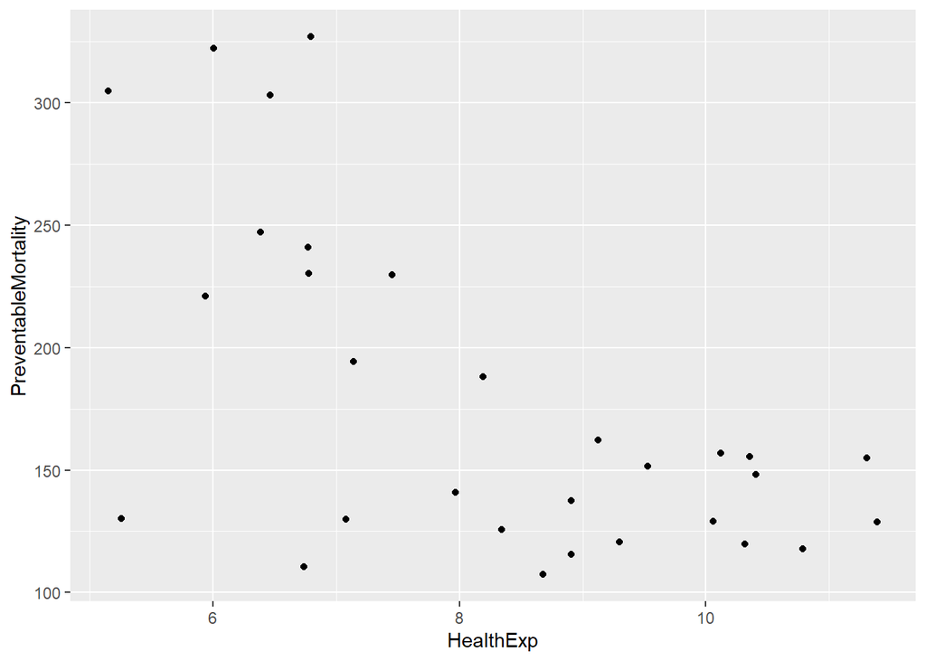

```r
ggplot(Mort, aes(x=HealthExp, y=PreventableMortality)) + geom_point()
```

Az ábrán szépen kirajzolódik a **negatív korreláció**: ha az $x$ tengelyen előrehaladunk, azaz az egészégügyi kiadások GDP százalékos arányát növeljük, akkor az $y$ tengelyen várhatóan *lefelé* kell lépnünk.  
Továbbá megfigyelhető a **kapcsolat közeoes erőssége** is: a pontokra aránylag jó pontossággal illeszthető egy negatív meredekségű egyenes, amitől a konkrét pontok *némileg eltérnek, de nem nagyon nagy mértékben*: a csökkenő tendencia még szemmel láthatóan kirajzolódik.

### 5.3. A regressziós egyenes

A második ponton menjünk tovább egy kicsit. Ez alapján a kapcsolat erőssége miatt a pontokra behúzható egy egyenes, ami az $R^2$ alapján a pontok alakulásának, szóródásának kb. $39\%$-át le tudja írni. Próbáljuk meg behúzni a fent pontdiagramon ezt a **pontokra legjobben illeszkedő egyenest**! A statisztikai szaknyelvben ennek az egyenesnek a neve **regressziós egyenes**.

A `ggplot` világában ezt a pontokra legjobban illeszkedő egyenest az ábrán egy `geom_smooth(method=lm)` réteg hozzáadásával lehet előcsalni:

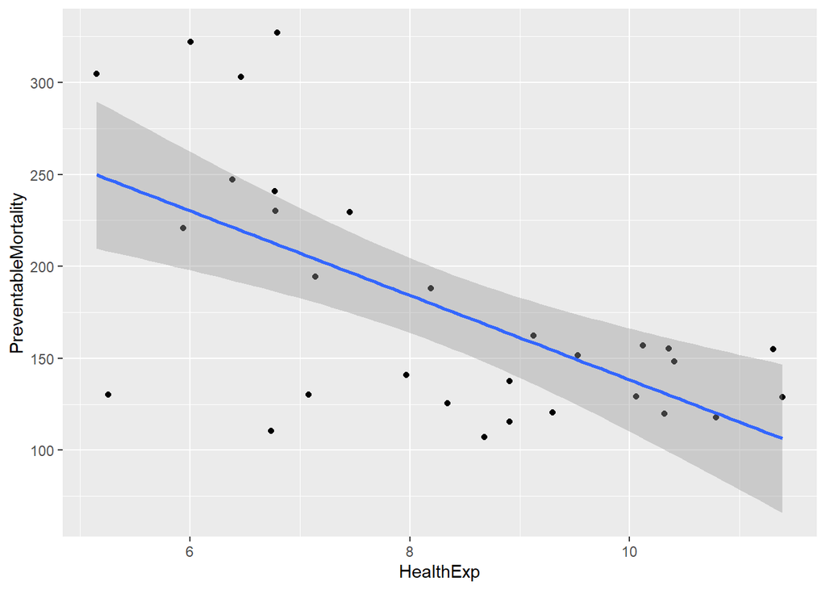

```r
ggplot(Mort, aes(x=HealthExp, y=PreventableMortality)) + geom_point() + geom_smooth(method=lm)
```

A csodaszép kék színű *regressziós egyenes* mellett egy **szürke sáv jelöli az egyenes 95%-os megbízhatóságú konfidencia-interavallumát**, tehát **ebben a sávban mozoghat a regressziós egyenes a mintán kívüli, tehát az adatbázisban nem megfigyelt országok körében 95%-os valószínűséggel**.  
Természetesen, ez a konfidencia-intervallum csak olyan országokra értendő, amelyek hasonlóan viselkednek a vizsgált változókban a jelen adatbázisban vizsgált 30 EU országhoz képest.

Láthatjuk tehát, hogy a pontokra legjobban illeszkedő egyenes **negatív meredekségű**, és bár **vannak pontok amik jobban eltérnek tőle, de a legtöbb konkrét ország azért követi az egyenes által felvázolt** ellentétes irányú **kapcsolatot**.  
Ez rímel arra, amit a **korreláció**ból is láttunk: a kapcsolat **ellentétes irányú és közepes erősségű**.

Ez mind szép és jó, de **honnan tudom leolvasni az egyenes egyenletét**?

Általánosságban egy egyenes egyenlete középiskolás ismereteink alapján a következő alakot ölti:
$$y=mx+b$$

Ebben a felírásban az $m$-et hívjuk az egyenes **meredekségének**, míg a $+b$ konstansot az egyenes **tengelymetszetének**, hiszen az egyenesünk az $y$ tengelyt pont az $x=0$ pontban, azaz $y=m \times 0 + b=b$-nél metszi.

Ez az általános felírás a statisztikában a következőre módosul:
$$\hat{y}=\beta_1x+\beta_0$$

A felírásban a **meredekség** $\beta_1$-é, a **tengelymetszet** $\beta_0$-á történő átkeresztelése csupán a görög betűk fetisizálásából jön. :)  
Ami viszont fontos, hogy **az $y$ koordináta $\hat{y}$-ra változott**!

Ez arra utal, hogy amikor egy tetszőleges ország $x$-ét **behelyettesítjük a regressziós egeynes egyenletébe**, akkor **csak egy becslést kapunk az $y$ értékére ($\hat{y}$), és NEM a valós $y$-t látjuk viszont**!  
Hiszen a regressziós egyenes pontossága az $R^2$ alapján csak $39\%$ és **NEM** $100\%$!!

Lássuk a jelenséget Magyarország példáján. Szűrjük le a `data frame`-t a magyar adatokra:

```r
Mort[Mort$Country=="Hungary",]
```

| Country | Smokers | HealthExp | PreventableMortality |
| --- | --- | --- | --- |
| Hungary | 25.8 | 6.792277 | 326.97 |

A magyar egészségügyi kiadások tehát kb. $6.79\%$-ot tesznek ki a GDP-ben, és 100 ezer főre $326.97$ megelőzhető haláleset jut. Ezt a párosítást az alábbi ábrán a *piros* pont jelöli. Ehhez képest a **regressziós egyenes szerint Magyarországon csak kb. $210$ megelőzhető halálesetnek kellene lennie 100 ezer főre** = *kék* pont.

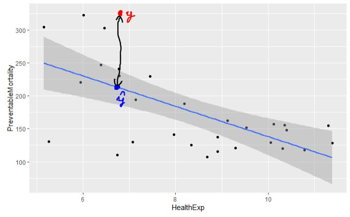

Ezen két érték közti különbség miatt számít az $y$ és $\hat{y}$ jelölés!

No, de akkor! Honnan is lesz meg nekünk a regressziós egyenes $\beta_1$ meredeksége és $\beta_0$ tengelymetszete?

Ehhez az R `lm` függvénye lesz segítségünkre, amivel létrehozzuk az R memóriájában a *regressziós modellt*, amiben benne lesznek a regressziós egyenes paraméterei, azaz $\beta$-i is!

A függvényben `eredményváltozó ~ magyarázóváltozó` módon adjuk meg $y$-t és $x$-et, majd a `data` paraméterben annak a `data frame`-nek a nevét kapja meg a függvény, amiben az eredményváltozó és a magyarázóváltozó lakik. Nagyon hasonló a dolog ahhoz, amit vegyes kapcsolatnál az `aov` függvényben is láttunk!

```r
lm(PreventableMortality ~ HealthExp, data = Mort)
```

```
##
## Call:
## lm(formula = PreventableMortality ~ HealthExp, data = Mort)
##
## Coefficients:
## (Intercept)    HealthExp
##      368.02       -22.98
```

Az `lm` eredményéből gyorsan le is olvashatjuk a regressziós együtthatókat:

- $\beta_0=368.02$
- $\beta_1=-22.98$

Tehát, a **teljes regressziós egyenes egyenlete**:
$$\hat{y}=368.02-22.98x$$

Használjuk is az egyenletet Magyarország kb. $x=6.79\%$-os GDP arányos egészségügyi kiadások esetére. Ekkor a *becsült* megelőzhető halálozások száma 100 ezer főre: $368.02-22.98 \times 6.79=211.9838$ fő. Ami $326.97-211.9838=114.9862$ fővel alacsonyabb, mint a valós érték.

A becsült eredményváltozó értékeket, azaz a $\hat{y}$-okat az R `predict` függvényével ki tudjuk számolni egy `data frame` minden megfigyelésére, azaz minden sorára is!  
Ehhez csak *el kell mentenünk az `lm` függvény eredményét* egy objektumba, és azt beadni a `predict` függvénynek a `data frame` nevével együtt, amibe a predikciókat akarjuk csinálni. A `data frame`-ben nyilván egy új oszlopot kell létrehozni `$` jellel a regressziós becsléseknek:

```r
RegModell <- lm(PreventableMortality ~ HealthExp, data = Mort)
Mort$BecsultHalal <- predict(RegModell, newdata = Mort)
head(Mort)
```

| Country | Smokers | HealthExp | PreventableMortality | BecsultHalal |
| --- | --- | --- | --- | --- |
| Hungary | 25.8 | 6.792277 | 326.97 | 211.9601 |
| Latvia | 24.1 | 6.006986 | 322.17 | 230.0028 |
| Romania | 19.8 | 5.150829 | 304.70 | 249.6736 |
| Lithuania | 20.2 | 6.465268 | 302.98 | 219.4734 |
| Estonia | 22.7 | 6.385947 | 247.08 | 221.2958 |
| Slovakia | 22.6 | 6.768882 | 240.86 | 212.4977 |

Láthatjuk, hogy megvan az új, **BecsultHalal** oszlopunk! Értéke Magyarországra pedig $211.96$! Ez kicsit eltér attól, amit mi számoltunk manuálisan, mert a $\beta$-k, amiket mi használtunk kerekített értékek voltak.

Ezen kívül fontos megjegyezni, hogy a regressziós egyenes $\beta_1$ és $\beta_0$ együtthatóinak **fontos jelentéstartalmat is tudunk adni**:

- $\beta_0$: Az **$x=0$ helyen becsült $y$**, azaz $\hat{y}$, amikor $x=0$. Csak akkor értelmezhető, ha az adatbázis szövegkörnyezetében az $x=0$ értelmezhető!
- $\beta_1$: Ez ugyebár egy meredekség, azaz megadja, hogy egyet lépünk jobbra a pontdiagram $x$ tengelyén, akkor mennyit kell lépni az $y$ tengelyen, hogy az egyenesen maradjunk. Ez statisztikásabban: **egy egység $x$ növekedés $\beta_1$-nyi $\hat{y}$ változással jár együtt**

Nézzük a dolgot konkrétaban, a mi együtthatóinkra:

```r
RegModell
```

```
##
## Call:
## lm(formula = PreventableMortality ~ HealthExp, data = Mort)
##
## Coefficients:
## (Intercept)    HealthExp
##      368.02       -22.98
```

A mi $\beta_0$-ánk most **egy elvi érték**, hiszen azt mondaná el, hogy az **az ország, ami a GDP 0 %-át költi a GDP-re, 100 ezer főre nézve $368.02$ megelőzhető halálesettel számolhat a modellünk szerint**. Nyilván, nincs olyan ország, ami 0%-ot költ GDP-re, így az eredmény egy elvi dolog. Bár az elég aggasztó, hogy Magyarország a $326.97$-es értékével ilyen közel áll a tengelymetszet értékéhez!

A mi $\beta_1$-ünk azt mondja most el, hogy ha a **GDP arányos egészségügyi kiadásait egy ország 1 százalékponttal megemeli, akkor várhatóan $22.98$ fővel kevesebb megelőzhető halálesettel számolhat 100 ezer főre**. Vagy, ha kicsit játszunk a mértékegységekkel, akkor azt is mondhatjuk, hogy **Ha a GDP 1 százalékponttal nagyobb részét költjük egészségügyre, akkor várhatóan durván 2.29 millió ($22.98 \times 10^5=2298000$) emberélet menthető meg**. De ez már nagyon demagóg…

A $\beta_1$ értelmezésnél **két dologról ne feledkezzetek el**:

1. Mindig legyen ott, hogy a $\beta_1$, csak az $\hat{y}$ változását, azaz a valós **$y$ várható változását** írja le!
2. Mind $x$-nek, mind $y$-nak a **saját mértékegységét** használjátok az értelmezés során. **Ne ragadjatok le az általános ‘egység’ szó használatánál**!

### 5.4. A regressziós egyenes együtthatóinak hipotézsvizsgálata

A **korrelációs kapcsolatok jelenlétét a sokaságban**, azaz a mintán kívüli világban, a regressziós egyenes **$\beta_1$ együtthatóján keresztül vizsgáljuk**.

Hiszen, ha a két mennyiségi változó közötti **kapcsolat**, amit a korrelációval mértünk **csak a mintavétreli hiba eredménye, és NEM áll fenn a sokaságban, akkor** ott egy egység $x$ növekedés $0$-val változtatja várhatóan $y$-t, azaz **$\beta_1=0$-nak vehető**.

Tehát, a következő $H_0$ és $H_1$ párost vizsgáljuk a korrelációs kapcsolat esetén:

- $H_0: \beta_1 = 0$
- $H_1: \beta_1 \neq 0$

A $H_1$-ben lévő $\neq$ jel miatt ez egy **kétoldali** hipotézisvizsgálat.

A próbához **p-érték**et úgy találunk, hogy a `summary` függvényt ráeresztjük az `lm` függvény eredményét tartalmazó R objektumra, ami jelen esetünkben **RegModell** névre hallgat:

```r
summary(RegModell)
```

```
##
## Call:
## lm(formula = PreventableMortality ~ HealthExp, data = Mort)
##
## Residuals:
##      Min       1Q   Median       3Q      Max
## -116.886  -31.824    3.071   25.667  115.010
##
## Coefficients:
##             Estimate Std. Error t value Pr(>|t|)
## (Intercept)  368.018     46.042   7.993 1.05e-08 ***
## HealthExp    -22.976      5.449  -4.217 0.000234 ***
## ---
## Signif. codes:  0 '***' 0.001 '**' 0.01 '*' 0.05 '.' 0.1 ' ' 1
##
## Residual standard error: 53.94 on 28 degrees of freedom
## Multiple R-squared:  0.3884, Adjusted R-squared:  0.3666
## F-statistic: 17.78 on 1 and 28 DF,  p-value: 0.0002343
```

Az eredményül kapott output táblában sok minden látszik. Pl. leolvasható az $R^2=0.3884\approx39\%$ is.  
De itt vannak a $\beta_1=-22.976$ és $\beta_0=368.018$ értékek is 3 tizedesjegy pontossággal a `Coefficients` tábla `Estimate` oszlopában.

De ami **nekünk kell, az a `Coefficients` tábla `Pr(>|t|)` oszlopában lakik**! Itt vannak a **p-értékek** a $H_0: \beta_j = 0$ és $H_1: \beta_j \neq 0$ hipotézis párokhoz! Nyilván a $j=0$ eset, azaz a **tengelymetszet nem érdekel minket**, de a **meredekség, azaz a $j=1$ eset igen**!  
Most pedig azt látjuk, hogy a **p-érték**ünk $0.000234$, ami **kisebb** mint a legksiebb szokásos szignifikancia-szint, azaz $\alpha=0.01$. Szóval minden szokásos stignifikancia-szinten **elutasítható** az a **$H_0$, miszerint a regressziós egyenes meredeksége a megfigyelt adatokon túli világban $0$** lenne!  
*Örömésbódogság* van! A regressziónk új megfigyeléseken, új országokon is használható! :)

Ami még érdekes lehet a nagy output táblázatból az a `Residual standard error: 53.94` rész. Ez a **reziduális standard hiba** megadja, hogy egy regresszióból **becsült $\hat{y}$ várhatóan/átlagosan mennyivel tér el a hozzá tartozó valós $y$-tól**!  
Esetünkben ez most annyit tesz, hogy **egy regressziós becslés a 100 ezer főre jutó megelőzhető halálozások számára várhatóan $\pm 53.94$-gyel tér el a valós megelőzhető halálozások számától**.  
Ezt a standard hibát használja amúgy a `ggplot` függvény is a regressziós egyenes 95%-os megbízhatóságú *konfidencia-interavllumának megszerkesztésére* is.

### 5.5 Regressziós mutatók a dohányzók aránya és a megelőzhető halálozások viszonylatában

Gyakorlásképpen gyorsan tekintsünk át egy regressziós összegző táblát akkor is, ha **magyarázóváltozó a dohányzó népesség aránya**, és az **eredményváltozó** továbbra is a **100 ezer főre jutó megelőzhető halálozások száma**.

Készítsük el a regressziós modell összegző tábláját R-ben:

```r
summary(lm(PreventableMortality ~ Smokers, data = Mort))
```

```
##
## Call:
## lm(formula = PreventableMortality ~ Smokers, data = Mort)
##
## Residuals:
##      Min       1Q   Median       3Q      Max
## -108.586  -35.220   -0.839   22.291  120.180
##
## Coefficients:
##             Estimate Std. Error t value Pr(>|t|)
## (Intercept)   57.448     41.599   1.381  0.17821
## Smokers        6.418      2.130   3.013  0.00544 **
## ---
## Signif. codes:  0 '***' 0.001 '**' 0.01 '*' 0.05 '.' 0.1 ' ' 1
##
## Residual standard error: 59.94 on 28 degrees of freedom
## Multiple R-squared:  0.2448, Adjusted R-squared:  0.2178
## F-statistic: 9.076 on 1 and 28 DF,  p-value: 0.005444
```

Majd vegyük sorra az eredményeket:

- A dohányzó népesség aránya kb. $24\%$-ban magyarázza a megelőzhető halálozások alakulását.
- Ha a népességben 1 százalékponttal több a dohányzó, az *várhatóan* $6.4$ fővel növeli a megelőzhető halálozásokat 100 ezer főre.
- Ez az előbbi hatás az országok sokaságában is jelentős, azaz **szignifikáns** marad, mivel a meredekséghez rendelt $0.00544$-es **p-érték alapján** a legkisebb szokásos szignifikanica szinten (1%) is **elutasítható** az a nullhipotézis, miszerint a **regressziós meredekség 0 lenne** a nem megfigyelt országok körében.
- A dohányzó népesség aránya alapján a regresszióból származó becslések a 100 ezer főre jutó megelőzhető halálozásra várhatóan $\pm 59.94$ fővel térnek el a valós értéktől.
- Ez a magasabb becslési hiba is azt mutatja, hogy a 100 ezer főre jutó megelőzhető halálozások száma jobban becsülhető a GDP arányos egészségügyi kiadásokkal (ha ez a magyarázóváltozó, akkor ez a hiba ugyebár $\pm 53.94$ fő volt), mint a dohányos népesség arányával.

Megnézhetjük, hogyan alakul a pontdiagramunk és a trendvonalunk akkor, ha az $x$ tengelyre a dohányzó népesség arányát rakjuk a GDP arányos egészségügyi kiadások helyett:

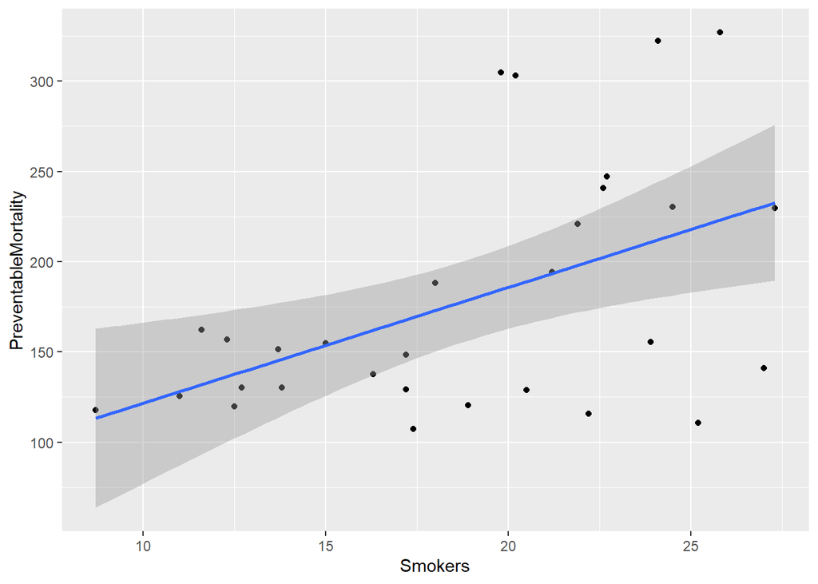

```r
ggplot(Mort, aes(x=Smokers, y=PreventableMortality)) + geom_point() + geom_smooth(method=lm)
```

Szépen kivehető azért a pontokból, hogy a **legjobban rájuk illesztehtő egyenes pozitív meredekségű**. Értelemszerűen ennek amúgy **meg kell egyeznie a két változó közti korreláció előjelével, ami itt szintén pozitív volt**:

```r
cor(Mort$PreventableMortality, Mort$Smokers)
```

```
## [1] 0.4947717
```

Érdemes továbbá megfigyelni, hogy az regressziós egyenes 95%-os megbízhatóságú **konfidencia-intervalluma kitágul az egyenes szélein, ahol aránylag kevés megfigyels található**. Ez egybevág azzal, amit a konfidencia-intervallumoktól tanultunk: az **elemszám növelésével pontosabb becsléseket kapunk, azaz csökkenteni lehet a konfidencia-intervallum hosszát a megbízhatósági szint változatlansága mellett is**!

## 6. Korrelációs kapcsolat egy minőségi változó szerint megbontva

Záróakkordként térjünk egy kicsit vissza a **CSOK** `data frame`-hez, és vizsgáljuk meg az ingatlan területének -**area** - és árának - **price** - kapcsolatát grafikusan pontdiagramon. Logikus módon legyen **terület a magyarázóváltozó és az ár az eredményváltozó**:

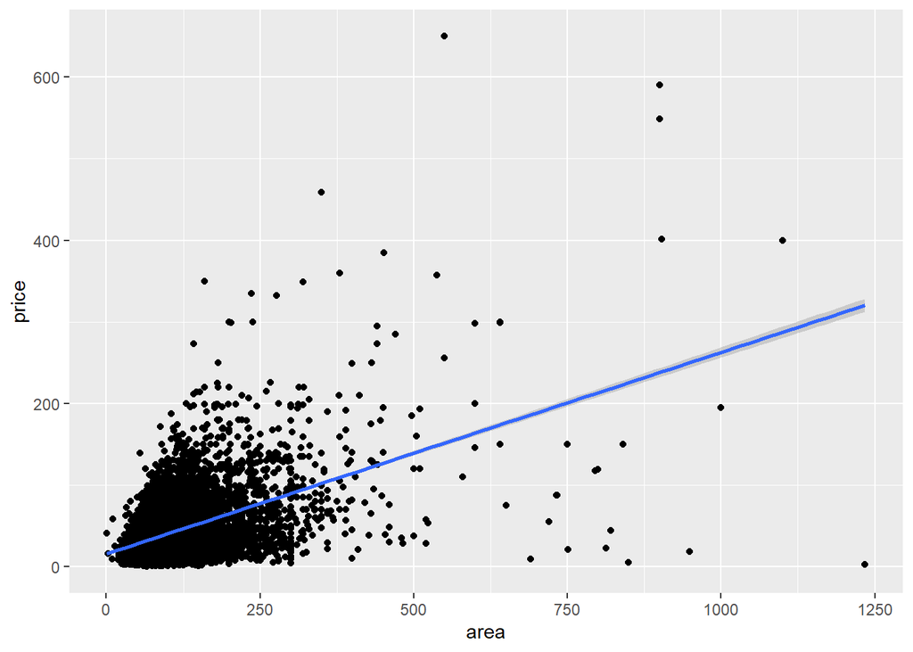

```r
ggplot(CSOK, aes(x=area, y=price)) + geom_point() + geom_smooth(method=lm)
```

Ez egy **szép egyirányú kapcsolat** (logikusan a terület növekedése jellemzően növeli az árakat), ami **közepes erősségűnek tűnik**: a pozitív meredekségű regressziós egyenes szépen kirajzolódik, de pár kilógó pont miatt azért messzebbre szakad az egyenestől.  
Mindez a korreláció $0.3$ és $0.7$ közötti abszolút értéke és poziítv előjele is megerősíti:

```r
cor(CSOK$area, CSOK$price)
```

```
## [1] 0.4824431
```

NODE, nézzük meg a kapcsolat alakulását egy **minőségi** változó, pl. **településtípus, azaz Settlement szerint külön-külön**! Ezt úgy tudjuk elérni, hogy a **pontokat megszínezzük településtípus szerint**!

Ezt úgy tudjuk eléreni, hogy a `ggplot`-ban az `aes` függvénybe becsempészünk egy `color=Settlement` beállítást:

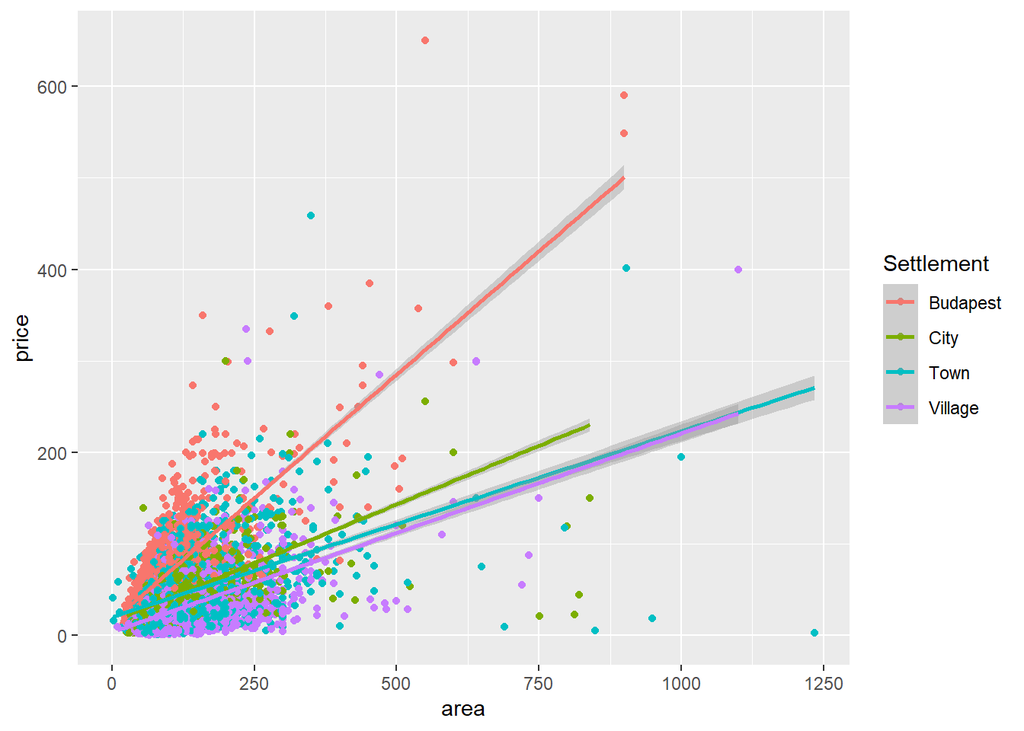

```r
ggplot(CSOK, aes(x=area, y=price, color=Settlement)) + geom_point() + geom_smooth(method=lm)
```

Voilá, a pontok szép színesek, és van **minden településtípusra külön regressziós egyenesünk is**! És nagyon szépen látjuk, hogy **Budapest egyenese meredekebb, azaz Budapesten egy extra négyzetméter jobban növeli az árat, mint a többi településtípusban**!

Még a **City kategória egyenese is meredekebben fut, mint a Town és Village egyenesek**.

Viszont, a **Town és Village egyenesekre azt mondhatjuk, hogy érdemben nem térnek el egymástól, mivel 95%-os konfidencia-intervallumuk több helyen is METSZ EGYMÁST**! tehát, 95%-os valószínűséggel a két regressziós egyenes azonos tartományon fut a megfigyelt ingatlanokon túli világban!

A konkrét **regressziós egyenesek egyenletei** most is egy `lm` függvényre eresztett `summary`-vel kaphatók meg. Csak a magyarázóváltozókhoz be kell pakolni `+` jellel elválasztva egy `Settlement*area` szorzatot:

```r
summary(lm(price ~ area + Settlement*area, data = CSOK))
```

```
##
## Call:
## lm(formula = price ~ area + Settlement * area, data = CSOK)
##
## Residuals:
##     Min      1Q  Median      3Q     Max
## -268.43  -13.71   -1.67   10.91  367.49
##
## Coefficients:
##                          Estimate Std. Error t value Pr(>|t|)
## (Intercept)             15.714208   0.801581  19.604  < 2e-16 ***
## area                     0.539137   0.007325  73.605  < 2e-16 ***
## SettlementCity          -0.402406   1.060455  -0.379    0.704
## SettlementTown           4.765932   1.046919   4.552 5.34e-06 ***
## SettlementVillage      -11.815975   1.087394 -10.866  < 2e-16 ***
## area:SettlementCity     -0.282870   0.009724 -29.089  < 2e-16 ***
## area:SettlementTown     -0.336183   0.009064 -37.091  < 2e-16 ***
## area:SettlementVillage  -0.322078   0.009213 -34.960  < 2e-16 ***
## ---
## Signif. codes:  0 '***' 0.001 '**' 0.01 '*' 0.05 '.' 0.1 ' ' 1
##
## Residual standard error: 23.17 on 15788 degrees of freedom
## Multiple R-squared:  0.4678, Adjusted R-squared:  0.4675
## F-statistic:  1982 on 7 and 15788 DF,  p-value: < 2.2e-16
```

Az eredményből több dolgot is leolvashatunk. Az **R-négyzet** most azt mutatja meg, hogy a **település típusa és a terület együttesen $46.78\%$-ban magyarázza meg a lakásárak alakulását**.

A `Coefficients` táblában pedig látunk egy alap `(Intercept)` és `area` értéket. No, ezek a **tábla lentebbi soraiban NEM szereplő Budapest regressziós egyenesének $\beta$ együtthatói**!  
A táblában lejjebb pedig megtalálható, hogy az **egyes településtípusokban a tengelymetszet, és a meredekség mennyivel TÉR EL Budapest értékeitől**!

Ezek alapján az **egyes településtípusok regressziós egyenesei az alábbiak**:

- **Budapest**: $\hat{price}=15.7+0.54 \times area$
- **City**: $\hat{price}=15.7-0.4+(0.54-0.28) \times area = 15.3+0.26 \times area$
- **Town**: $\hat{price}=15.7+4.8+(0.54-0.34) \times area = 20.5+0.20 \times area$
- **Village**: $\hat{price}=15.7-11.8+(0.54-0.32) \times area = 3.9+0.22 \times area$

Ezek alapján Budapesten egy extra négyzetméter várhatóan $0.54$ MFt-tal (540 EFt-tal) növeli az árakat, míg egyéb kisvárosokban (Town) csak $0.20$ MFt-tal (200 EFt-tal).

A `Coefficients` tábla `Pr(>|t|)` oszlopában lévő **p-értékek**ből látszik, hogy csak egy együtthatóra tudjuk elfogadni minden szokásos $\alpha$-n (azaz még a legnagyobb $10\%$-on is) azt a $H_0$-t, hogy ő a sokaságban $0$-nak vehető: a **SettlementCity**-ra, $0.704=70.4\%$-os p-értékkel.  
Ez az együttható pedig a **City**-k regressziós egyenesének **tengelymetszetét módosítja Budapest regressziós egyenesének tengelymetszetéhez képest**. Na, **ez a változás $0$-nak vehető az ingatlanok sokaságában**. Tehát az, hogy ez itt most $-0.40$ lett és nem csont $0$, az *csak a mintavételi hiba műve*.

Érdekességképpen megnézhetjük, hogy mi van akkor, ha a **referencia egyenes NEM Budapest, hanem mondjuk a Village**. Ezt beállítani az R `relevel` függvényéval lehet az alábbi módon:

```r
CSOK$Settlement <- relevel(CSOK$Settlement, ref = "Village")
```

Ezek után futtassuk újra a regresszió eredményeit:

```r
summary(lm(price ~ area + Settlement*area, data = CSOK))
```

```
##
## Call:
## lm(formula = price ~ area + Settlement * area, data = CSOK)
##
## Residuals:
##     Min      1Q  Median      3Q     Max
## -268.43  -13.71   -1.67   10.91  367.49
##
## Coefficients:
##                          Estimate Std. Error t value Pr(>|t|)
## (Intercept)              3.898234   0.734774   5.305 1.14e-07 ***
## area                     0.217059   0.005588  38.845  < 2e-16 ***
## SettlementBudapest      11.815975   1.087394  10.866  < 2e-16 ***
## SettlementCity          11.413569   1.010903  11.290  < 2e-16 ***
## SettlementTown          16.581906   0.996695  16.637  < 2e-16 ***
## area:SettlementBudapest  0.322078   0.009213  34.960  < 2e-16 ***
## area:SettlementCity      0.039208   0.008493   4.616 3.94e-06 ***
## area:SettlementTown     -0.014105   0.007728  -1.825    0.068 .
## ---
## Signif. codes:  0 '***' 0.001 '**' 0.01 '*' 0.05 '.' 0.1 ' ' 1
##
## Residual standard error: 23.17 on 15788 degrees of freedom
## Multiple R-squared:  0.4678, Adjusted R-squared:  0.4675
## F-statistic:  1982 on 7 and 15788 DF,  p-value: < 2.2e-16
```

Láthatjuk, hogy most a **Village** egyenletet kapjuk meg alapból, ami ugyebár $\hat{price}=3.9+0.22 \times area$ volt 2 tizedesjegyre.

**Budapest korábbi egyenlete is szépen kijön** $\hat{price}=3.9+11.8+(0.22+0.32) \times area=15.7+0.54 \times area$ módon.

Ezen kívül látni a **p-értékek**ből, hogy a **Town** egyenesek **meredeksége csak $\alpha=10\%$-on tér el a sokaságban is a Village meredekségtől, a többi szignifikancia-szinten NEM**! Ez egybevág azzal, hogy a **két településtípus regressziós egyeneseinek 95%-os konfidencia-intervalluma metszi egymást**.